# NAIVE BAYES APLICADO AL CONJUNTO DE DATOS IRIS

FCO. EMMANUEL DORANTES CAÑA

24/11/26

# 1. Introducción

Naive Bayes es un clasificador probabilístico basado en el **teorema de Bayes**. Se llama “ingenuo” (naive) porque supone que los atributos son **independientes entre sí** dado la clase.

Queremos saber la probabilidad de que una observación pertenezca a la clase $c$ dados sus atributos $x_1, \dots, x_n$:

$$P(c \mid x_1,\dots,x_n) \propto
P(c)\prod_{i=1}^{n} P(x_i \mid c)$$

Se calcula la probabilidad para cada clase y se elige la **mayor**.

La probabilidad a priori de cada clase es simplemente su frecuencia en el conjunto de entrenamiento:

$$P(c) = \frac{n_c}{N}$$

donde $n_c$ es el número de registros de la clase $c$ y $N$ el total de registros.

Como los atributos de Iris son numéricos, `naiveBayes` los modela con una **distribución normal** (gaussiana) por clase, usando la media y la desviación estándar de cada atributo en cada clase.

# 2. Paquetes

```r
# Si no los tienes, instálalos una sola vez en la consola:
# install.packages(c("e1071", "caret", "ggplot2"))

library(e1071)   # contiene la función naiveBayes
library(caret)   # partición de datos y evaluación del modelo
library(ggplot2) # visualización
```

# 3. Carga y exploración de datos

El conjunto Iris ya viene incluido en R: 150 flores de 3 especies, con 4 medidas cada una.

```r
data(iris)
str(iris)
```

```
## 'data.frame':    150 obs. of  5 variables:
##  $ Sepal.Length: num  5.1 4.9 4.7 4.6 5 5.4 4.6 5 4.4 4.9 ...
##  $ Sepal.Width : num  3.5 3 3.2 3.1 3.6 3.9 3.4 3.4 2.9 3.1 ...
##  $ Petal.Length: num  1.4 1.4 1.3 1.5 1.4 1.7 1.4 1.5 1.4 1.5 ...
##  $ Petal.Width : num  0.2 0.2 0.2 0.2 0.2 0.4 0.3 0.2 0.2 0.1 ...
##  $ Species     : Factor w/ 3 levels "setosa","versicolor",..: 1 1 1 1 1 1 1 1 1 1 ...
```

```r
head(iris)
```

```
##   Sepal.Length Sepal.Width Petal.Length Petal.Width Species
## 1          5.1         3.5          1.4         0.2  setosa
## 2          4.9         3.0          1.4         0.2  setosa
## 3          4.7         3.2          1.3         0.2  setosa
## 4          4.6         3.1          1.5         0.2  setosa
## 5          5.0         3.6          1.4         0.2  setosa
## 6          5.4         3.9          1.7         0.4  setosa
```

```r
summary(iris)
```

```
##   Sepal.Length    Sepal.Width     Petal.Length    Petal.Width
##  Min.   :4.300   Min.   :2.000   Min.   :1.000   Min.   :0.100
##  1st Qu.:5.100   1st Qu.:2.800   1st Qu.:1.600   1st Qu.:0.300
##  Median :5.800   Median :3.000   Median :4.350   Median :1.300
##  Mean   :5.843   Mean   :3.057   Mean   :3.758   Mean   :1.199
##  3rd Qu.:6.400   3rd Qu.:3.300   3rd Qu.:5.100   3rd Qu.:1.800
##  Max.   :7.900   Max.   :4.400   Max.   :6.900   Max.   :2.500
##        Species
##  setosa    :50
##  versicolor:50
##  virginica :50
##
##
##
```

Verificamos si hay valores faltantes (NA):

```r
sum(is.na(iris))
```

```
## [1] 0
```

Distribución de las clases (deben ser 50 de cada una):

```r
table(iris$Species)
```

```
##
##     setosa versicolor  virginica
##         50         50         50
```

Gráfico de dispersión de todos los pares de variables, coloreado por especie:

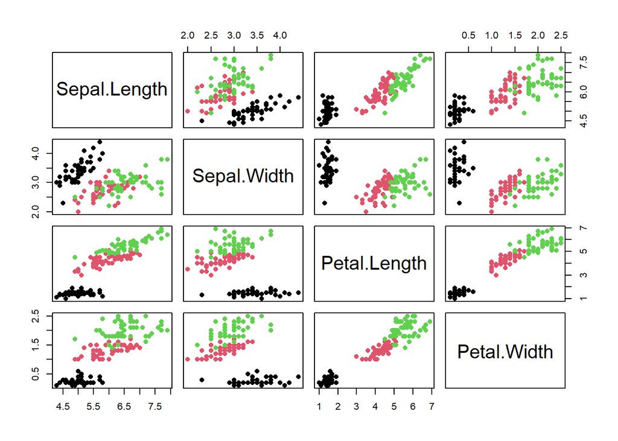

```r
pairs(iris[, 1:4], col = iris$Species, pch = 16)
```

# 4. División en entrenamiento y prueba

Usamos 70% de los datos para entrenar y 30% para probar. `createDataPartition` mantiene la misma proporción de especies en ambos conjuntos. La semilla (`set.seed`) hace que el resultado sea reproducible.

```r
set.seed(123)
train_index <- createDataPartition(iris$Species, p = 0.7, list = FALSE)

train_data <- iris[train_index, ]
test_data  <- iris[-train_index, ]

dim(train_data)
```

```
## [1] 105   5
```

```r
dim(test_data)
```

```
## [1] 45  5
```

# 5. Entrenamiento del modelo

En la fórmula `Species ~ .`, `Species` es lo que queremos predecir y el punto significa “usa todas las demás variables”.

```r
modelo_nb <- naiveBayes(Species ~ ., data = train_data)
print(modelo_nb)
```

```
##
## Naive Bayes Classifier for Discrete Predictors
##
## Call:
## naiveBayes.default(x = X, y = Y, laplace = laplace)
##
## A-priori probabilities:
## Y
##     setosa versicolor  virginica
##  0.3333333  0.3333333  0.3333333
##
## Conditional probabilities:
##             Sepal.Length
## Y                [,1]      [,2]
##   setosa     4.991429 0.3657156
##   versicolor 5.942857 0.4558674
##   virginica  6.631429 0.6846087
##
##             Sepal.Width
## Y                [,1]      [,2]
##   setosa     3.365714 0.3455114
##   versicolor 2.777143 0.3227508
##   virginica  2.982857 0.3222035
##
##             Petal.Length
## Y                [,1]      [,2]
##   setosa     1.471429 0.1808012
##   versicolor 4.262857 0.4222389
##   virginica  5.591429 0.5741344
##
##             Petal.Width
## Y                 [,1]       [,2]
##   setosa     0.2314286 0.09321521
##   versicolor 1.3285714 0.20518489
##   virginica  2.0342857 0.25775371
```

```r
modelo_nb$apriori
```

```
## Y
##     setosa versicolor  virginica
##         35         35         35
```

Probabilidades condicionales: para cada atributo y clase se guarda la **media** (columna 1) y la **desviación estándar** (columna 2).

```r
modelo_nb$tables
```

```
## $Sepal.Length
##             Sepal.Length
## Y                [,1]      [,2]
##   setosa     4.991429 0.3657156
##   versicolor 5.942857 0.4558674
##   virginica  6.631429 0.6846087
##
## $Sepal.Width
##             Sepal.Width
## Y                [,1]      [,2]
##   setosa     3.365714 0.3455114
##   versicolor 2.777143 0.3227508
##   virginica  2.982857 0.3222035
##
## $Petal.Length
##             Petal.Length
## Y                [,1]      [,2]
##   setosa     1.471429 0.1808012
##   versicolor 4.262857 0.4222389
##   virginica  5.591429 0.5741344
##
## $Petal.Width
##             Petal.Width
## Y                 [,1]       [,2]
##   setosa     0.2314286 0.09321521
##   versicolor 1.3285714 0.20518489
##   virginica  2.0342857 0.25775371
```

# 6. Predicciones

```r
predicciones <- predict(modelo_nb, test_data)

head(predicciones)       # lo que predijo el modelo
```

```
## [1] setosa setosa setosa setosa setosa setosa
## Levels: setosa versicolor virginica
```

```r
head(test_data$Species)  # los valores reales
```

```
## [1] setosa setosa setosa setosa setosa setosa
## Levels: setosa versicolor virginica
```

# 7. Evaluación del modelo

La **matriz de confusión** compara lo predicho (filas) contra lo real (columnas). La diagonal son los aciertos.

```r
confusion_matrix <- table(Predicho = predicciones, Real = test_data$Species)
print(confusion_matrix)
```

```
##             Real
## Predicho     setosa versicolor virginica
##   setosa         15          0         0
##   versicolor      0         13         2
##   virginica       0          2        13
```

```r
precision <- sum(diag(confusion_matrix)) / sum(confusion_matrix)
cat("Precisión:", precision, "\n")
```

```
## Precisión: 0.9111111
```

Métricas más detalladas con `caret`:

```r
confusionMatrix(predicciones, test_data$Species)
```

```
## Confusion Matrix and Statistics
##
##             Reference
## Prediction   setosa versicolor virginica
##   setosa         15          0         0
##   versicolor      0         13         2
##   virginica       0          2        13
##
## Overall Statistics
##
##                Accuracy : 0.9111
##                  95% CI : (0.7878, 0.9752)
##     No Information Rate : 0.3333
##     P-Value [Acc > NIR] : 8.467e-16
##
##                   Kappa : 0.8667
##
##  Mcnemar's Test P-Value : NA
##
## Statistics by Class:
##
##                      Class: setosa Class: versicolor Class: virginica
## Sensitivity                 1.0000            0.8667           0.8667
## Specificity                 1.0000            0.9333           0.9333
## Pos Pred Value              1.0000            0.8667           0.8667
## Neg Pred Value              1.0000            0.9333           0.9333
## Prevalence                  0.3333            0.3333           0.3333
## Detection Rate              0.3333            0.2889           0.2889
## Detection Prevalence        0.3333            0.3333           0.3333
## Balanced Accuracy           1.0000            0.9000           0.9000
```

# 8. Predicción de nuevas observaciones

```r
nuevos_datos <- data.frame(
  Sepal.Length = c(5.1, 6.7, 5.8),
  Sepal.Width  = c(3.5, 3.0, 2.7),
  Petal.Length = c(1.4, 5.2, 4.2),
  Petal.Width  = c(0.2, 2.3, 1.3)
)

predict(modelo_nb, nuevos_datos)
```

```
## [1] setosa     virginica  versicolor
## Levels: setosa versicolor virginica
```

Probabilidades de cada clase para cada observación:

```r
predict(modelo_nb, nuevos_datos, type = "raw")
```

```
##             setosa   versicolor    virginica
## [1,]  1.000000e+00 8.913737e-20 5.114392e-26
## [2,] 1.785606e-203 1.268812e-06 9.999987e-01
## [3,]  9.123989e-80 9.998715e-01 1.285303e-04
```

# 9. Conclusiones